# Statistics_and_R_Project_1

Firtst_author

2024-10-11

## EDA (Exploratory data analysis)

Сперва взглянем глазами на данные, с которыми нам предстоит работать. Первый этап представляет собой предварительный анализ полученного датасета. Посмотрим, какие у нас переменные, сколько у нас наблюдений и есть ли между ними взаимосвязь. Также на данном этапе необходимо установить, есть ли в датасете пропущенные значения, обнаружить наличие или отсутствие выбросов, а также определить, что делать с наблюдениями, которые их содержат.

Основные задачи:

1. Понимание структуры данных (сколько, какой тип, дубликаты, пропущенные и тд)
2. Выявление выбросов
3. Определение связей между переменными
4. Подготовка данных для дальнейшего анализа

### Обзор данных и работа с пропущенными значениями

```r
library(dplyr)
library(ggplot2)
library(tidyverse)
library(psych)
library(pheatmap)
main_dir <- dirname(rstudioapi::getSourceEditorContext()$path)
setwd(main_dir)
```

```r
data_day <- read.csv("day.csv")
str(data_day)
```

```
## 'data.frame':    731 obs. of  16 variables:
##  $ instant   : int  1 2 3 4 5 6 7 8 9 10 ...
##  $ dteday    : chr  "2011-01-01" "2011-01-02" "2011-01-03" "2011-01-04" ...
##  $ season    : int  1 1 1 1 1 1 1 1 1 1 ...
##  $ yr        : int  0 0 0 0 0 0 0 0 0 0 ...
##  $ mnth      : int  1 1 1 1 1 1 1 1 1 1 ...
##  $ holiday   : int  0 0 0 0 0 0 0 0 0 0 ...
##  $ weekday   : int  6 0 1 2 3 4 5 6 0 1 ...
##  $ workingday: int  0 0 1 1 1 1 1 0 0 1 ...
##  $ weathersit: int  2 2 1 1 1 1 2 2 1 1 ...
##  $ temp      : num  0.344 0.363 NA 0.2 0.227 ...
##  $ atemp     : num  0.364 0.354 0.189 0.212 0.229 ...
##  $ hum       : num  0.806 0.696 0.437 0.59 0.437 ...
##  $ windspeed : num  0.16 0.249 0.248 0.16 0.187 ...
##  $ casual    : int  331 131 120 108 82 88 148 68 54 41 ...
##  $ registered: int  654 670 1229 1454 1518 1518 1362 891 768 1280 ...
##  $ cnt       : int  985 801 1349 1562 1600 1606 1510 959 822 1321 ...
```

```r
summary(data_day)
```

```
##     instant         dteday              season            yr
##  Min.   :  1.0   Length:731         Min.   :1.000   Min.   :0.0000
##  1st Qu.:183.5   Class :character   1st Qu.:2.000   1st Qu.:0.0000
##  Median :366.0   Mode  :character   Median :3.000   Median :1.0000
##  Mean   :366.0                      Mean   :2.497   Mean   :0.5007
##  3rd Qu.:548.5                      3rd Qu.:3.000   3rd Qu.:1.0000
##  Max.   :731.0                      Max.   :4.000   Max.   :1.0000
##
##       mnth          holiday           weekday        workingday
##  Min.   : 1.00   Min.   :0.00000   Min.   :0.000   Min.   :0.000
##  1st Qu.: 4.00   1st Qu.:0.00000   1st Qu.:1.000   1st Qu.:0.000
##  Median : 7.00   Median :0.00000   Median :3.000   Median :1.000
##  Mean   : 6.52   Mean   :0.02873   Mean   :2.997   Mean   :0.684
##  3rd Qu.:10.00   3rd Qu.:0.00000   3rd Qu.:5.000   3rd Qu.:1.000
##  Max.   :12.00   Max.   :1.00000   Max.   :6.000   Max.   :1.000
##
##    weathersit         temp             atemp              hum
##  Min.   :1.000   Min.   :0.05913   Min.   :0.07907   Min.   :0.0000
##  1st Qu.:1.000   1st Qu.:0.33750   1st Qu.:0.33784   1st Qu.:0.5194
##  Median :1.000   Median :0.50000   Median :0.48673   Median :0.6283
##  Mean   :1.395   Mean   :0.49600   Mean   :0.47435   Mean   :0.6279
##  3rd Qu.:2.000   3rd Qu.:0.65583   3rd Qu.:0.60860   3rd Qu.:0.7303
##  Max.   :3.000   Max.   :0.86167   Max.   :0.84090   Max.   :0.9725
##                  NA's   :2                           NA's   :5
##    windspeed           casual         registered        cnt
##  Min.   :0.02239   Min.   :   2.0   Min.   :  20   Min.   :  22
##  1st Qu.:0.13495   1st Qu.: 315.5   1st Qu.:2502   1st Qu.:3152
##  Median :0.18097   Median : 713.0   Median :3664   Median :4548
##  Mean   :0.19050   Mean   : 848.2   Mean   :3659   Mean   :4504
##  3rd Qu.:0.23322   3rd Qu.:1096.0   3rd Qu.:4783   3rd Qu.:5956
##  Max.   :0.50746   Max.   :3410.0   Max.   :6946   Max.   :8714
##  NA's   :1                          NA's   :1
```

Как можно заметить, в наших данных присутствуют NA значения, а именно в переменных temp, hum, windspeed, registered Также необходимо проверить, есть ли значения с пустыми строками:

```r
data_day$dteday <- as.Date(data_day$dteday) # Преобразуем переменную dteday из character в класс Date
data_day_na <- data_day %>%
  mutate(across(where(~ !is.Date(.)), ~ ifelse(. == "", NA, .)))
```

Таким образом количество NA не увеличилось, что говорит об отсутствии пустых ячеек ““. Можем взглянуть на строки с NA

```r
 data_day_na[!complete.cases(data_day),]
```

```
##     instant     dteday season yr mnth holiday weekday workingday weathersit
## 3         3 2011-01-03      1  0    1       0       1          1          1
## 12       12 2011-01-12      1  0    1       0       3          1          1
## 14       14 2011-01-14      1  0    1       0       5          1          1
## 25       25 2011-01-25      1  0    1       0       2          1          2
## 157     157 2011-06-06      2  0    6       0       1          1          1
## 159     159 2011-06-08      2  0    6       0       3          1          1
## 683     683 2012-11-13      4  1   11       0       2          1          2
## 687     687 2012-11-17      4  1   11       0       6          0          1
## 729     729 2012-12-29      1  1   12       0       6          0          2
##         temp    atemp      hum windspeed casual registered  cnt
## 3         NA 0.189405 0.437273  0.248309    120       1229 1349
## 12  0.172727 0.160473       NA  0.304627     25       1137 1162
## 14  0.160870 0.188413       NA  0.126548     54       1367 1421
## 25  0.223478 0.234526 0.616957  0.129796    186         NA 1985
## 157 0.678333 0.621858       NA  0.121896    673       3875 4548
## 159 0.775833 0.727279       NA  0.136817    676       3725 4401
## 683       NA 0.323225 0.662917  0.342046    327       3767 4094
## 687 0.325000 0.326383 0.545417        NA   1313       4316 5629
## 729 0.253333 0.242400       NA  0.124383    159       1182 1341
```

Поскольку в нашем датасете достаточно данных, то можем удалить все наблюдения с пропущенными значения (NA).

```r
bicycle_rent_clean <- na.omit(data_day_na)
```

После удаления NA значений преобразуем наш датасет в более читаемый вид, переименовав некоторые значения переменных. Для удобства в переменной `yr` заменим 0 на 2011 и 1 на 2012 соотвественно.

```r
bicycle_rent_clean_fix <-  bicycle_rent_clean %>% mutate(yr = case_when(
  yr == 0 ~ 2011,
  yr == 1 ~ 2012,
  TRUE ~ as.numeric(yr)))
```

### Работа с выбросами

На данном этапе попробуем построить различные графики, которые позволяют обнаружить подозрительные значения, похожие на выбросы. Сперва посмотри на месяц и сезоны.

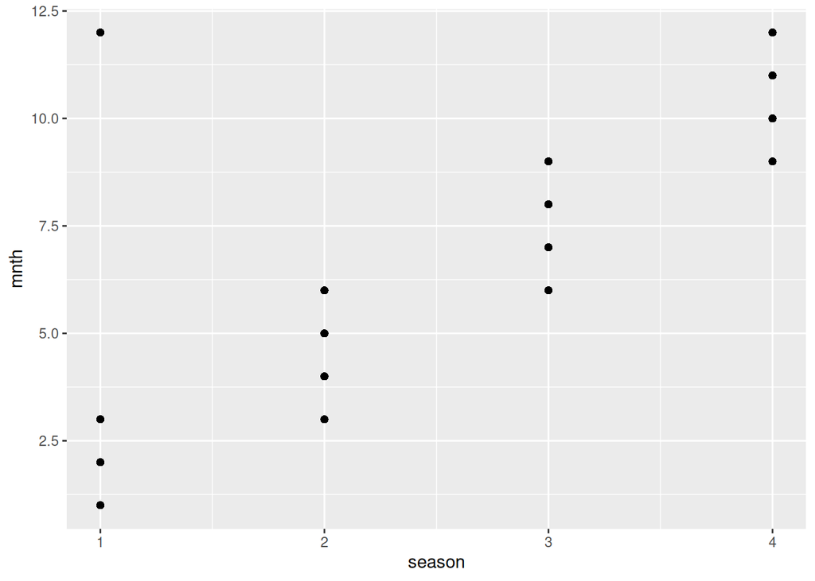

```r
ggplot(bicycle_rent_clean_fix, aes(x = season, y =mnth))+
  geom_point()
```

```r
filter(bicycle_rent_clean_fix, season==1 & instant > 600)
```

```
##    instant     dteday season   yr mnth holiday weekday workingday weathersit
## 1      721 2012-12-21      1 2012   12       0       5          1          2
## 2      722 2012-12-22      1 2012   12       0       6          0          1
## 3      723 2012-12-23      1 2012   12       0       0          0          1
## 4      724 2012-12-24      1 2012   12       0       1          1          2
## 5      725 2012-12-25      1 2012   12       1       2          0          2
## 6      726 2012-12-26      1 2012   12       0       3          1          3
## 7      727 2012-12-27      1 2012   12       0       4          1          2
## 8      728 2012-12-28      1 2012   12       0       5          1          2
## 9      730 2012-12-30      1 2012   12       0       0          0          1
## 10     731 2012-12-31      1 2012   12       0       1          1          2
##        temp    atemp      hum windspeed casual registered  cnt
## 1  0.326667 0.301767 0.556667 0.3743830    221       3402 3623
## 2  0.265833 0.236113 0.441250 0.4073460    205       1544 1749
## 3  0.245833 0.259471 0.515417 0.1330830    408       1379 1787
## 4  0.231304 0.258900 0.791304 0.0772304    174        746  920
## 5  0.291304 0.294465 0.734783 0.1687260    440        573 1013
## 6  0.243333 0.220333 0.823333 0.3165460      9        432  441
## 7  0.254167 0.226642 0.652917 0.3501330    247       1867 2114
## 8  0.253333 0.255046 0.590000 0.1554710    644       2451 3095
## 9  0.255833 0.231700 0.483333 0.3507540    364       1432 1796
## 10 0.215833 0.223487 0.577500 0.1548460    439       2290 2729
```

Может показаться, что верхняя точка является выбросом, но это не так, поскольку 12 месяц также относится к зиме

Попробуем другой график для `atemp` и `season`

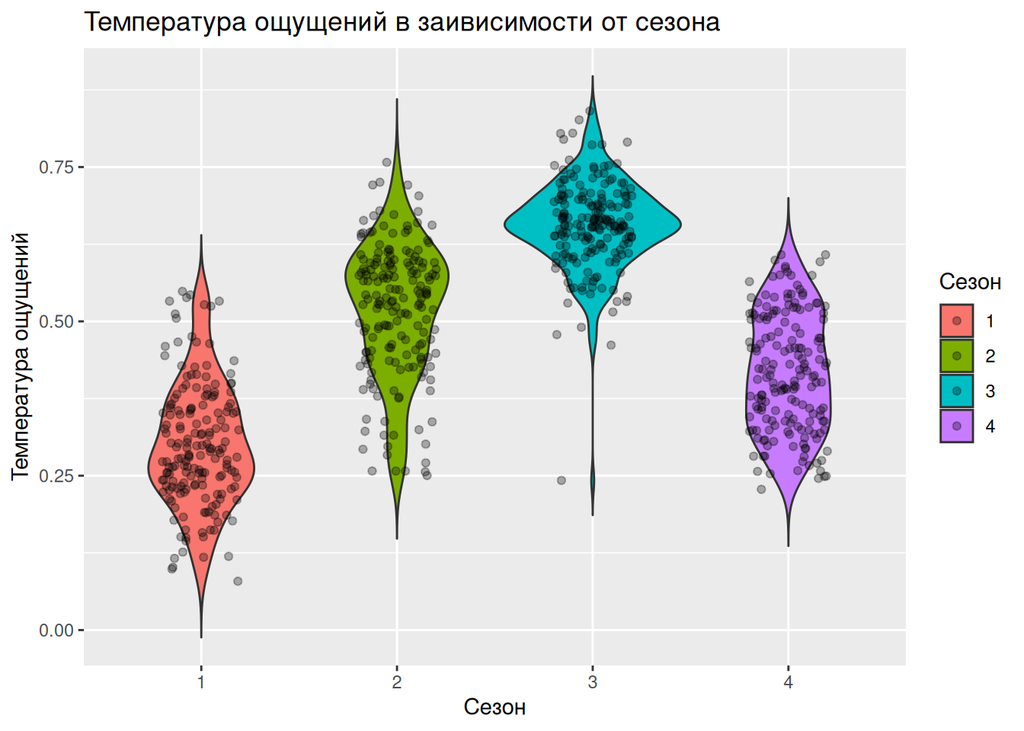

```r
ggplot(bicycle_rent_clean_fix, aes(x = as.factor(season), y = atemp, fill = as.factor(season))) +
  geom_violin(trim = FALSE) +
  geom_jitter(width = 0.2, alpha = 0.3, color = "black") +  # Добавим рассеянные точки для каждого значения
  labs(x = "Сезон", y = "Температура ощущений", fill = "Сезон") +
  ggtitle("Температура ощущений в заивисимости от сезона")
```

**Violin Plot** показывает распределение данных для каждого сезона с помощью формы графика плотности. С помощью `geom_jitter` нанесли все наблюдения на график. Можно заметить, что есть подозрительное значение `atemp` в один из дней лета. Выведем это значение.

```r
filter(bicycle_rent_clean_fix, season==3 & atemp < 0.4)
```

```
##   instant     dteday season   yr mnth holiday weekday workingday weathersit
## 1     595 2012-08-17      3 2012    8       0       5          1          1
##       temp  atemp      hum windspeed casual registered  cnt
## 1 0.723333 0.2424 0.570833  0.231354   1483       5665 7148
```

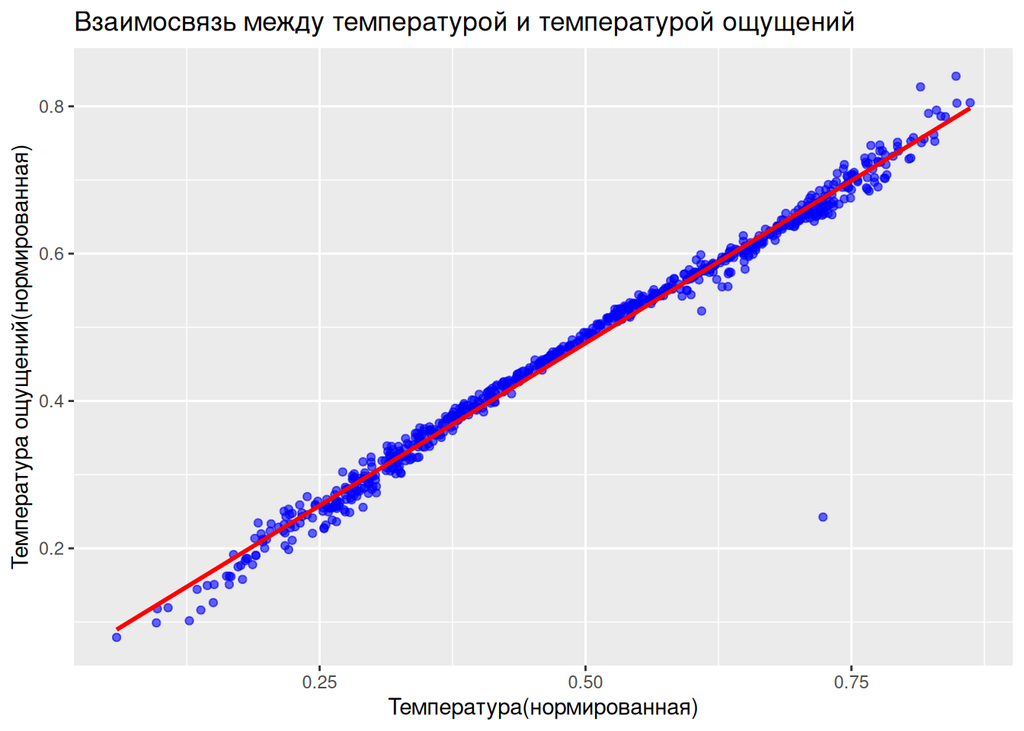

```r
ggplot(bicycle_rent_clean_fix, aes(x = temp, y = atemp)) +
  geom_point(alpha = 0.6, color = "blue") +
  geom_smooth(method = "lm", formula = y ~ x, color = "red", se = FALSE) +  # Линия тренда
  labs(x = "Температура(нормированная)", y = "Температура ощущений(нормированная)") +
  ggtitle("Взаимосвязь между температурой и температурой ощущений")
```

Несложно заметить, что одно из значений явно выбивается. Это как раз наш летний день с температурой ощущения 12.1 градусов Цельсия. Исключаем его.

```r
bicycle_rent_clean_fix_f1 <- filter(bicycle_rent_clean_fix, !(season == '3' & atemp < 0.4))
```

Теперь взглянем на зависимость влажности от месяца

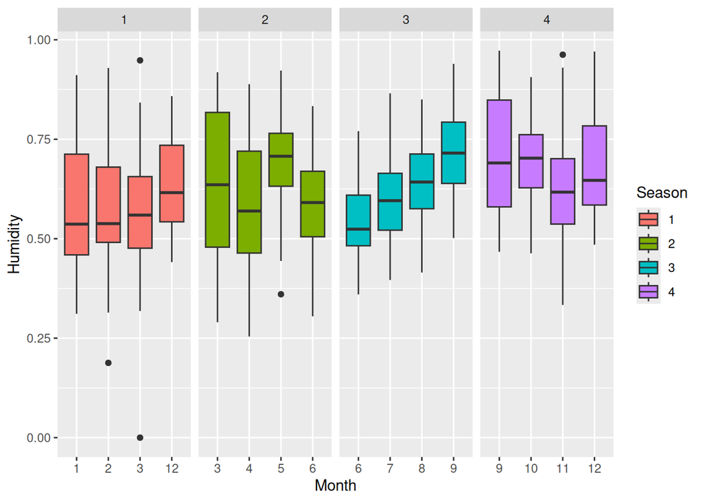

```r
ggplot(bicycle_rent_clean_fix_f1, aes(x = factor(mnth), y = hum)) +
  geom_boxplot(aes(fill = factor(season))) +
  labs(x = "Month", y = "Humidity", fill = "Season") +
  facet_grid(. ~ season, scales = "free_x", space = "free_x")
```

```r
bicycle_rent_clean_fix_f2 <-  filter(bicycle_rent_clean_fix_f1, !( mnth == 3 & hum < 0.1))
```

В третьем месяце видим значение влажности равное 0, что очевидно является выбросом. Чтобы решить, что делать со значениями, которые выходят за 1,5 межквартильных размаха, взглянем на другие переменные в датасете.

```r
filtered_data <- bicycle_rent_clean_fix_f2 %>%
  filter((mnth == 2 & hum < 0.25) |
         (mnth == 3 & hum > 0.92) |
         (mnth == 5 & hum < 0.4)  |
         (mnth == 11 & hum > 0.95))
filtered_data
```

```
##   instant     dteday season   yr mnth holiday weekday workingday weathersit
## 1      50 2011-02-19      1 2011    2       0       6          0          1
## 2      65 2011-03-06      1 2011    3       0       0          0          2
## 3     326 2011-11-22      4 2011   11       0       2          1          3
## 4     497 2012-05-11      2 2012    5       0       5          1          1
##       temp    atemp      hum windspeed casual registered  cnt
## 1 0.399167 0.391404 0.187917  0.507463    532       1103 1635
## 2 0.376522 0.366252 0.948261  0.343287    114        491  605
## 3 0.416667 0.421696 0.962500  0.118792     69       1538 1607
## 4 0.533333 0.520833 0.360417  0.236937   1319       5711 7030
```

### Поиск взаимосвязей

Мы исключили выбросы и пропущенные значения и теперь перейдем к выявлению взаимосвязи между переменными. Для этого оставим только числовые переменные.

```r
bicycle_numeric_data <- bicycle_rent_clean_fix_f2 %>%
  select_if(is.numeric)
```

Для выявления взаимосвязи посмотрим наличие корреляции с помощью библиотеки `psych`

```r
corr.test(bicycle_numeric_data)
```

```
## Call:corr.test(x = bicycle_numeric_data)
## Correlation matrix
##            instant season    yr  mnth holiday weekday workingday weathersit
## instant       1.00   0.40  0.86  0.48    0.02   -0.01       0.01      -0.02
## season        0.40   1.00 -0.02  0.83   -0.01    0.00       0.02       0.02
## yr            0.86  -0.02  1.00 -0.02    0.01   -0.01       0.01      -0.05
## mnth          0.48   0.83 -0.02  1.00    0.02    0.00       0.01       0.04
## holiday       0.02  -0.01  0.01  0.02    1.00   -0.10      -0.25      -0.03
## weekday      -0.01   0.00 -0.01  0.00   -0.10    1.00       0.04       0.03
## workingday    0.01   0.02  0.01  0.01   -0.25    0.04       1.00       0.06
## weathersit   -0.02   0.02 -0.05  0.04   -0.03    0.03       0.06       1.00
## temp          0.15   0.33  0.04  0.22   -0.03    0.00       0.05      -0.12
## atemp         0.15   0.34  0.05  0.23   -0.04    0.00       0.06      -0.12
## hum           0.00   0.20 -0.12  0.22   -0.02   -0.05       0.03       0.62
## windspeed    -0.12  -0.24 -0.01 -0.21    0.01    0.02      -0.02       0.04
## casual        0.27   0.20  0.24  0.12    0.05    0.06      -0.52      -0.25
## registered    0.66   0.40  0.59  0.29   -0.11    0.06       0.31      -0.26
## cnt           0.63   0.40  0.57  0.27   -0.07    0.07       0.07      -0.29
##             temp atemp   hum windspeed casual registered   cnt
## instant     0.15  0.15  0.00     -0.12   0.27       0.66  0.63
## season      0.33  0.34  0.20     -0.24   0.20       0.40  0.40
## yr          0.04  0.05 -0.12     -0.01   0.24       0.59  0.57
## mnth        0.22  0.23  0.22     -0.21   0.12       0.29  0.27
## holiday    -0.03 -0.04 -0.02      0.01   0.05      -0.11 -0.07
## weekday     0.00  0.00 -0.05      0.02   0.06       0.06  0.07
## workingday  0.05  0.06  0.03     -0.02  -0.52       0.31  0.07
## weathersit -0.12 -0.12  0.62      0.04  -0.25      -0.26 -0.29
## temp        1.00  1.00  0.12     -0.16   0.54       0.53  0.62
## atemp       1.00  1.00  0.14     -0.18   0.54       0.54  0.63
## hum         0.12  0.14  1.00     -0.25  -0.09      -0.11 -0.12
## windspeed  -0.16 -0.18 -0.25      1.00  -0.17      -0.22 -0.24
## casual      0.54  0.54 -0.09     -0.17   1.00       0.39  0.67
## registered  0.53  0.54 -0.11     -0.22   0.39       1.00  0.94
## cnt         0.62  0.63 -0.12     -0.24   0.67       0.94  1.00
## Sample Size
## [1] 720
## Probability values (Entries above the diagonal are adjusted for multiple tests.)
##            instant season   yr mnth holiday weekday workingday weathersit temp
## instant       0.00   0.00 0.00 0.00    1.00    1.00       1.00       1.00 0.00
## season        0.00   0.00 1.00 0.00    1.00    1.00       1.00       1.00 0.00
```

[output cut: 16 more lines]

```
## yr          1.00 0.05      1.00    0.0       0.00 0.00
## mnth        0.00 0.00      0.00    0.1       0.00 0.00
## holiday     1.00 1.00      1.00    1.0       0.13 1.00
## weekday     1.00 1.00      1.00    1.0       1.00 1.00
## workingday  1.00 1.00      1.00    0.0       0.00 1.00
## weathersit  0.06 0.00      1.00    0.0       0.00 0.00
## temp        0.00 0.05      0.00    0.0       0.00 0.00
## atemp       0.00 0.01      0.00    0.0       0.00 0.00
## hum         0.00 0.00      0.00    0.9       0.18 0.08
## windspeed   0.00 0.00      0.00    0.0       0.00 0.00
## casual      0.00 0.02      0.00    0.0       0.00 0.00
## registered  0.00 0.00      0.00    0.0       0.00 0.00
## cnt         0.00 0.00      0.00    0.0       0.00 0.00
##
##  To see confidence intervals of the correlations, print with the short=FALSE option
```

Однако для более лучшей наглядности воспользуемся библиотекой `pheatmap`. Данная библиотека позволяет построить тепловую карту для наших данных. Она более удобна в сравнении с функций `melt` из пакета `ggplot2` и не требует преобразования матрицы в подходящий формат.

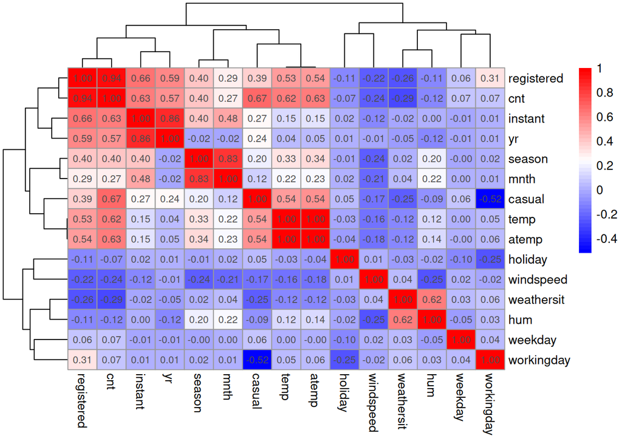

```r
library(pheatmap)
corr_matrix <- corr.test(bicycle_numeric_data)$r
pheatmap(corr_matrix,
         color = colorRampPalette(c("blue", "white", "red"))(50),
         display_numbers = TRUE)
```

Таким образом, можно наблюдать корреляцию между некоторыми переменнами. Например, температура и температура ощущений, что было продемонстрировано ранее. Также есть сильная взаимосвязь между количеством зарегистрированных пользователей и общим количеством прокатов и чуть более слабая между обычными пользователями и общим количеством прокатов. Также есть некоторая корреляция между количеством пользователей и температурой, погодой и влажностью. Также есть средняя отрицательная корреляция между количеством незарегестрированных пользователей и выходным/рабочим днем.

### Проверка гипотез

Мы проанализировали датасет. Температура`temp` и количество пользователей `cnt`показали довольно сильную корреляцию.

1. Давайте проверим гипотезу о том, что есть статистически значимая зависимость между данными переменными.
   1. Нулевая гипотеза: Температура и количество пользователей независимы. Альтернативная гипотеза: Температура и количество пользователей зависят друг от друга.
   2. Зафиксируем уровень значимости - 0.05
   3. Используем коэффициент корреляции Пирсона
   4. Получаем значение статистики и p-value

```r
cor_test_result <- cor.test(bicycle_rent_clean_fix_f2$cnt, bicycle_rent_clean_fix_f2$temp, method = "pearson")
```

Таким образом, на основании корреляционного анализа мы можем заключить, что верна альтернативная гипотеза и количество прокатов зависит от температуры (p-value = 1.0517799^{-78}, значение статистики 21.3531075 )

2. Проверим гипотезу о росте популярности проката велосипедов и самокатов с 2011 по 2012 год. Для этого разобьем датасет на 2 года
   1. Нулевая гипотеза: Нет значимого роста количества пользователей проката между 2011 и 2012 годами, то есть среднее количество пользователей за оба года одинаково Количество пользователей в 2012 году значительно больше, чем в 2011 году, то есть среднее количество пользователей за 2012 год больше, чем за 2011 год
   2. Зафиксируем уровень значимости - 0.05
   3. Используем Т-критерия Стьюдента для независимыз выборок
   4. Рассчитаем статистику и p-value

```r
year_2011_bicycle_rent_clean <- bicycle_rent_clean_fix %>% filter(yr == 2011)
year_2012_bicycle_rent_clean <- bicycle_rent_clean_fix %>% filter(yr == 2012)

bicycle_rent_clean_fix <-  bicycle_rent_clean_fix %>%
  mutate(yr = as.numeric(yr))


t_test_result <- t.test(year_2011_bicycle_rent_clean$registered,   year_2012_bicycle_rent_clean$registered)
bicycle_rent_clean_fix <-  bicycle_rent_clean_fix %>%
  mutate(yr = as.numeric(yr))
test_result <-  t.test(year_2011_bicycle_rent_clean$registered,   year_2012_bicycle_rent_clean$registered)
```

На основании двухстороннего двухвыборочного Т-критерия Стьюдента мы можем заключить, что в 2012 году прокат велосипедов стал популярнее в сравнении с 2011 годом. p-value составил 6.5115854^{-70}, статистика t = -19.9631116

3. Проверим гипотезу о зависимости состояния погоды и количества прокатов. Нулевая гипотеза: Распределение количества прокатов по различным состояниям погоды одинаково. Альтернативная гипотеза: Распределение количества прокатов по различным состояниям погоды отличается. Создадим таблицу сопряженности для проверки связи между состоянием погоды `weathersit` и тем, превышает ли количество прокатов `cnt` медианное значение.

```r
table(bicycle_rent_clean_fix_f2$weathersit, bicycle_rent_clean_fix_f2$cnt > median(bicycle_rent_clean_fix_f2$cnt))
```

```
##
##     FALSE TRUE
##   1   188  268
##   2   153   91
##   3    19    1
```

```r
chisq_result <-  chisq.test(table(bicycle_rent_clean_fix_f2$weathersit, bicycle_rent_clean_fix_f2$cnt > median(bicycle_rent_clean_fix_f2$cnt)))
```

В колонке TRUE записао количество прокатов, превышающих медианное значение для трех состояний погды. В FALSE количество, не превышающее медианное значение. Таким образом, стостояние погоды действительно влияет на количество прокатов (p-value: 1.0317515^{-10}, X-squared:45.9891861)

```
1)  Проверим еще одну гипотезу: есть ли различия в количестве прокатов в рабочие и выходные дни.
2)  Будем использовать непараметрический критерий Манна-Уитни.
3)  Уровень значимости зададим 0.05
4)  Нулевая гипотеза: распределение количества прокатов одинаково в рабочие и нерабочие дни. Альтернативная гипотеза: Распределение количества прокатов отличается в рабочие и нерабочие дни.
5)  Считаем статистику
```

```r
mann_whitney_test <- wilcox.test(cnt ~ workingday, data = bicycle_rent_clean_fix_f2)
```

Таким образом верна нулевая гипотеза и распределение количества прокатов не отличается в рабочие и нерабочие дни. p.value = 0.0909988, статистика = 5.1826^{4}